# MSDS Case Study 2: Predicting Attrition & Monthly Income

Ahmad Salama

2023-12-09

#### Presentation Link:

#### https://smu365-my.sharepoint.com/:v:/g/personal/asalama_smu_edu/EcvIvC4ET19Ipb9VwXKlxJkBAz27C0XmR9YxaSd295wuTw?e=kky6gI

## Introduction

Ladies and Gentlemen, CEO and CFO of Frito Lay, my name is Ahmad Salama and I am honored to present my data exploration and analysis of the employee data set you have provided. Our goal is to address and report any noteworthy observations and identify factors that lead to employee attrition and provide a regression model to help in predicting the monthly income for the employee.

Now, let’s dive into our data exploration and analysis.

```r
# set a seed to make randomness reproducible
seed_value <- 9864
split_perc <- 0.65
# default theme for all plots:
default_ggtheme <- theme_gray()
```

```r
# set the session working directory to current project working directory.
setwd(getwd())

# load the CaseStudy2 data into memory:
raw_employee_data <- read.csv("data/CaseStudy2-data.csv", header = TRUE)

# load the CaseStudy2CompSet No Attrition data into memory:
raw_employee_data_with_no_attrition <- read.csv("data/CaseStudy2CompSet No Attrition.csv", header = TRUE)

# load the CaseStudy2CompSet No Salary data into memory:
raw_employee_data_with_no_comp <- read.csv("data/CaseStudy2CompSet No Salary.csv", header = TRUE)
raw_employee_data_with_no_comp$JobLevel <- as.factor(raw_employee_data_with_no_comp$JobLevel)
```

## Explroing the Data

Let’s start by reviewing a description of basic information in the provided employee data set. As you can see from the visuals below, the data set has 870 observations and 36 variables: 27 continuous variables and nine discrete variables. Furthermore, there are no missing values in our data set. This completeness ensures the reliability and accuracy of our insights, setting the stage for a robust analysis.

```r
# using the introduce function from the data explorer package to print out some basic information
gather(introduce(raw_employee_data), key = "Key", value = "Value")
```

```
##                    Key  Value
## 1                 rows    870
## 2              columns     36
## 3     discrete_columns      9
## 4   continuous_columns     27
## 5  all_missing_columns      0
## 6 total_missing_values      0
## 7        complete_rows    870
## 8   total_observations  31320
## 9         memory_usage 167096
```

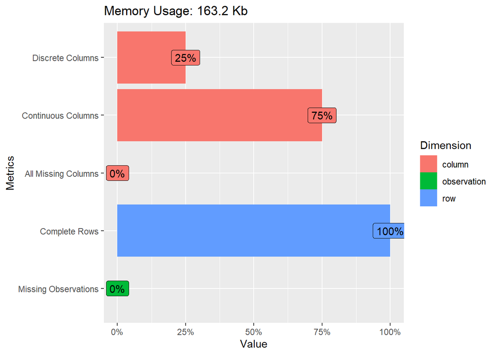

```r
# using the plot_intro to visualize other basic information
plot_intro(raw_employee_data, ggtheme = default_ggtheme)
```

Now, let’s look at our data by creating bar charts for each discrete feature, providing a clear view of our data set’s distribution and frequencies of categorical variables.

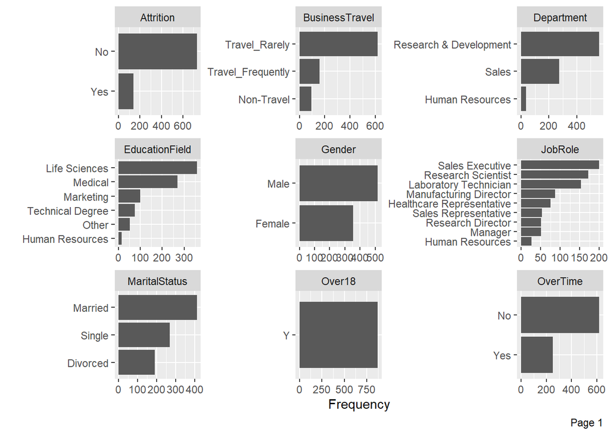

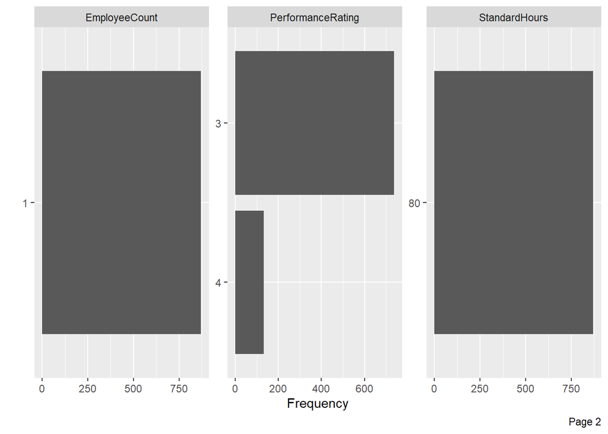

```r
# create bar charts for each discrete feature
plot_bar(raw_employee_data, ggtheme = default_ggtheme)
```

When it comes to our continuous features, beginning with histograms for each variable will offer a valuable description of the frequency distribution of data. Histograms provide a visual means to comprehend our data set’s central tendency and spread, enabling us to gain insights into the patterns and characteristics of the continuous variables.

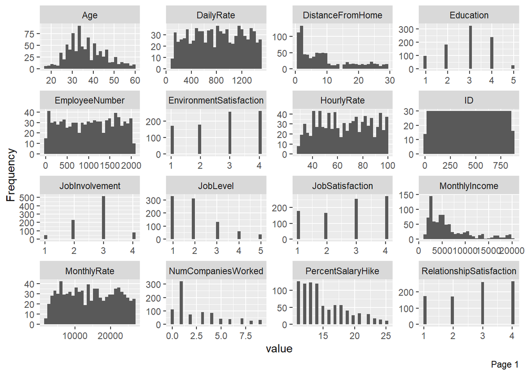

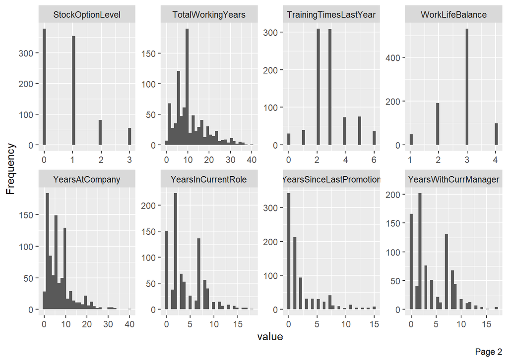

```r
# create histograms for each of the continuous variables
plot_histogram(raw_employee_data, ggtheme = default_ggtheme)
```

During this initial exploratory data analysis, we identified constant and insignificant variables across all observations: “Over18”, “StandardHours”, and “EmployeeCount”. Moreover, we’ve determined that certain variables, like “ID” and “EmployeeNumber” are irrelevant to our data analysis. Additionally, it’s worth underscoring that “EmployeeNumber” is considered sensitive information. Therefore, we recommend excluding such data points before sharing the data set with third parties to protect employee privacy. Hence, we will drop those variables in subsequent stages of data processing.

```r
# drop constant and insignificant variables from the data set:
raw_employee_data <- raw_employee_data %>%
  drop_columns(c("EmployeeNumber", "EmployeeCount", "ID", "Over18", "StandardHours"))
```

Furthermore, several continuous features can be transformed into discrete variables due to their limited values. For instance, the “WorkLifeBalance” variable offers only four options: 1, 2, 3, and 4. Therefore, converting it into a categorical variable could yield more meaningful insights for our analysis.

It’s also important to highlight that performance ratings in our data set are limited to two values: 3 and 4. Assuming a typical scale of 1 to 5, where 5 represents the highest performance, it’s evident that our observations are imbalanced and primarily consist of high performers. This imbalance could influence our analysis, introducing bias into the results.

In addition to the performance ratings, there exists a significant imbalance within the data set, particularly in specific crucial categories to our analysis such as “Attrition”, “JobRle”, “Department”, and “EducationField”. The concern is that our models may may not achieve optimal precision and recall across all categories.

Below a bar charts with percentage for each of the mentioned column above. Here the takeaways:

- 84% of the collected observation are for employee who didn’t leave and stayed with the company.
- 64% of the employee are from the Research & Development Department.
- 41% of the participants have life sciences as their education field.
- 60% of the participants have one of the following job roles: Sales Executive, Research Scientist, and Laboratory Technician.

```r
# convert continuous variables to categorical factors:
raw_employee_data <- convert_to_discrete_factors(raw_employee_data)
raw_employee_data$AttritionAsNumeric <- as.integer(raw_employee_data$Attrition)
```

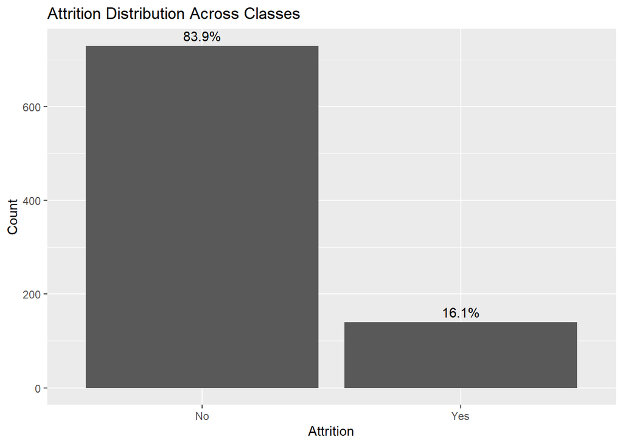

```r
raw_employee_data %>%
  ggplot(mapping = aes(x = Attrition)) +
  geom_bar() +
  geom_text(
    stat = "count",
    aes(label = paste0(round(after_stat(count)/sum(after_stat(count)) * 100, 1), "%")),
    vjust = -0.5,
    show.legend = FALSE
  ) +
  ylab("Count") +
  ggtitle("Attrition Distribution Across Classes") +
  default_ggtheme
```

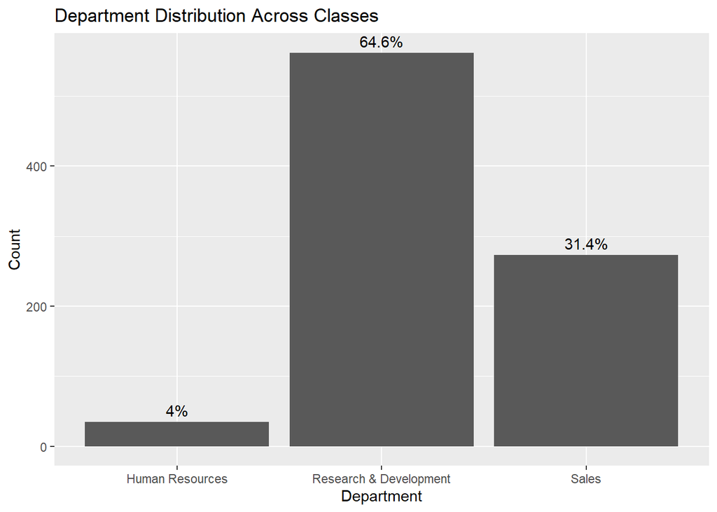

```r
raw_employee_data %>%
  ggplot(mapping = aes(x = Department)) +
  geom_bar() +
  geom_text(
    stat = "count",
    aes(label = paste0(round(after_stat(count)/sum(after_stat(count)) * 100, 1), "%")),
    vjust = -0.5,
    show.legend = FALSE
  ) +
  ylab("Count") +
  ggtitle("Department Distribution Across Classes") +
  default_ggtheme
```

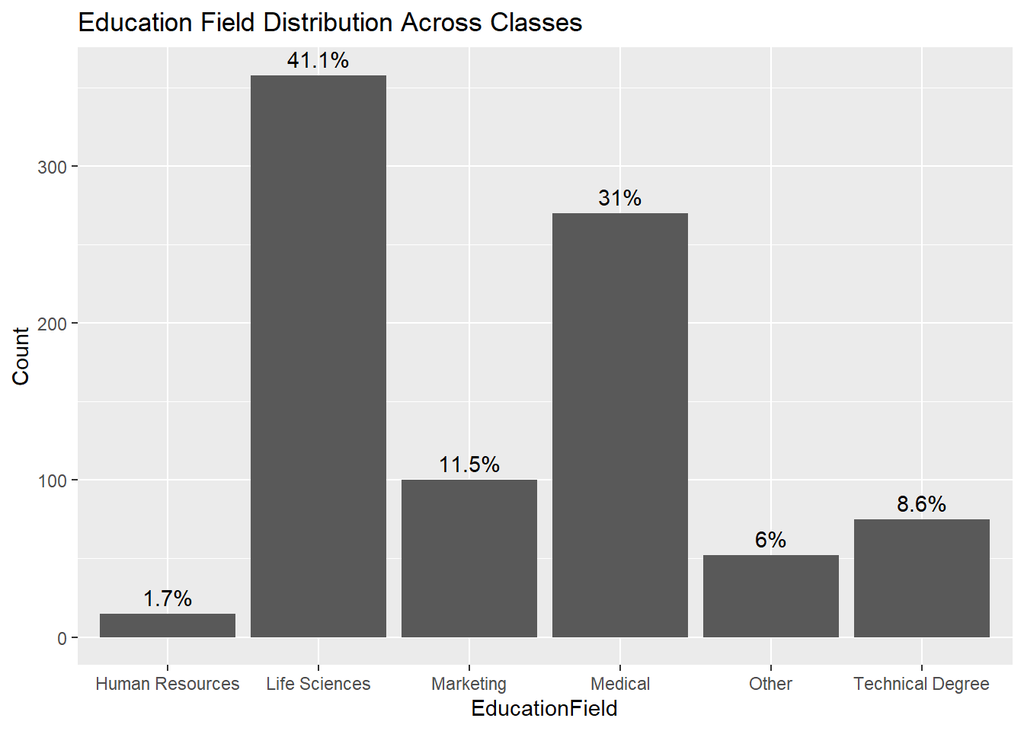

```r
raw_employee_data %>%
  ggplot(mapping = aes(x = EducationField)) +
  geom_bar() +
  geom_text(
    stat = "count",
    aes(label = paste0(round(after_stat(count)/sum(after_stat(count)) * 100, 1), "%")),
    vjust = -0.5,
    show.legend = FALSE
  ) +
  ylab("Count") +
  ggtitle("Education Field Distribution Across Classes") +
  default_ggtheme
```

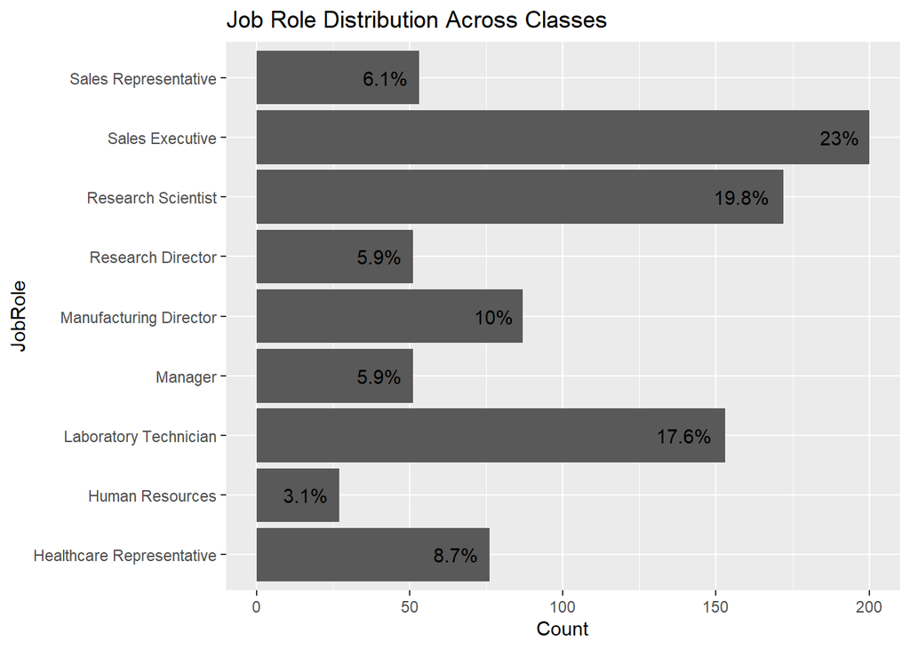

```r
raw_employee_data %>%
  ggplot(mapping = aes(y = JobRole)) +
  geom_bar() +
  geom_text(
    stat = "count",
    aes(label = paste0(round(after_stat(count)/sum(after_stat(count)) * 100, 1), "%")),
    hjust = 1.25,
    show.legend = FALSE
  ) +
  xlab("Count") +
   ggtitle("Job Role Distribution Across Classes") +
  default_ggtheme
```

Now, let’s review the correlation between our variables. We will be focused on finding correlations between Attrition and MonthlyIncome with other variables.

```r
# select all numeric variables from the data set:
numeric_variables <- raw_employee_data %>%
  select(where(is.numeric))

#plot correlation for attrition with all of the other continuous variables:
correlation_numeric_with_attrition_table <- numeric_variables %>%
  correlate() %>%
  focus(AttritionAsNumeric)
```

```
## Correlation computed with
## • Method: 'pearson'
## • Missing treated using: 'pairwise.complete.obs'
```

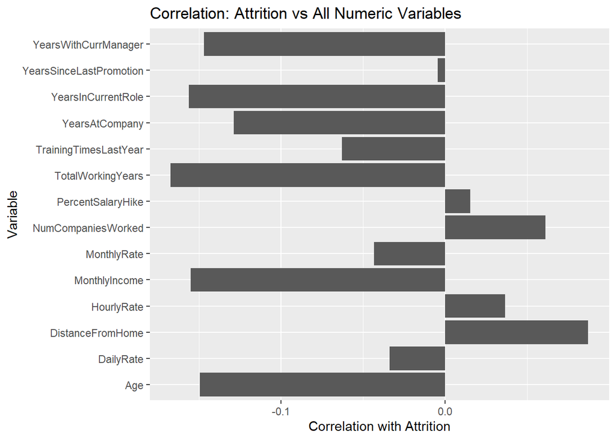

```r
correlation_numeric_with_attrition_table %>%
  ggplot(aes(y = term, x = AttritionAsNumeric)) +
  geom_bar(stat = "identity") +
  xlab("Correlation with Attrition") +
  ylab("Variable") +
  ggtitle("Correlation: Attrition vs All Numeric Variables")
```

```r
#plot correlation for monthly income with all of the other continuous variables:
correlation_numeric_with_monthlyIncome_table <- numeric_variables %>%
  correlate() %>%
  focus(MonthlyIncome)
```

```
## Correlation computed with
## • Method: 'pearson'
## • Missing treated using: 'pairwise.complete.obs'
```

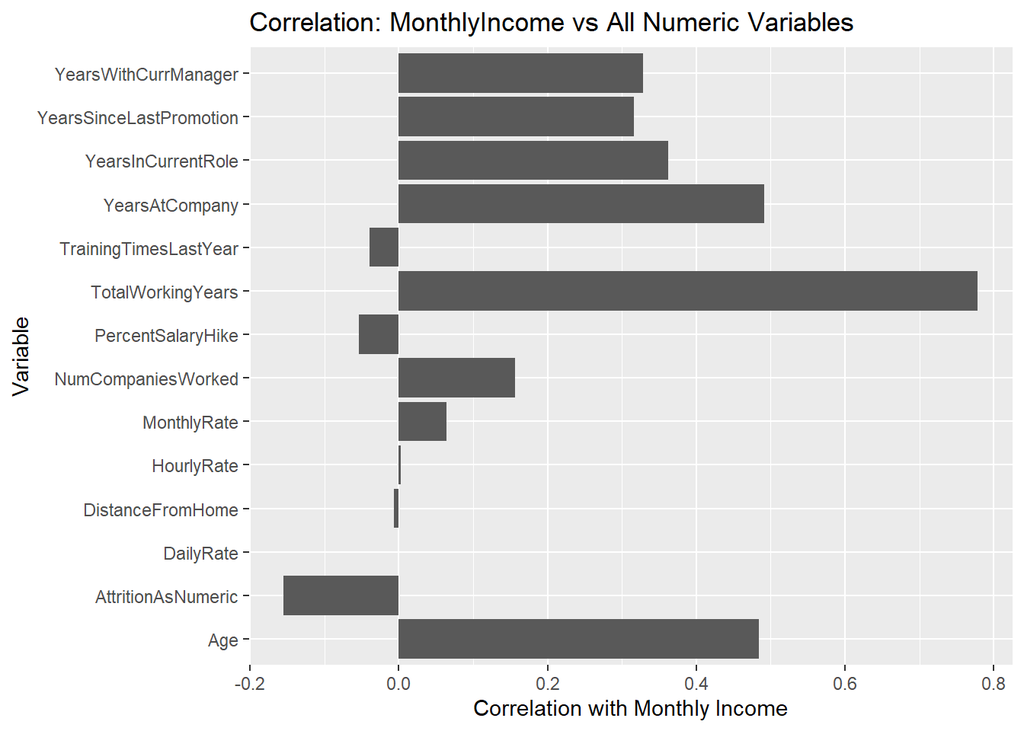

```r
correlation_numeric_with_monthlyIncome_table %>%
  ggplot(aes(y = term, x = MonthlyIncome)) +
  geom_bar(stat = "identity") +
  xlab("Correlation with Monthly Income") +
  ylab("Variable") +
  ggtitle("Correlation: MonthlyIncome vs All Numeric Variables")
```

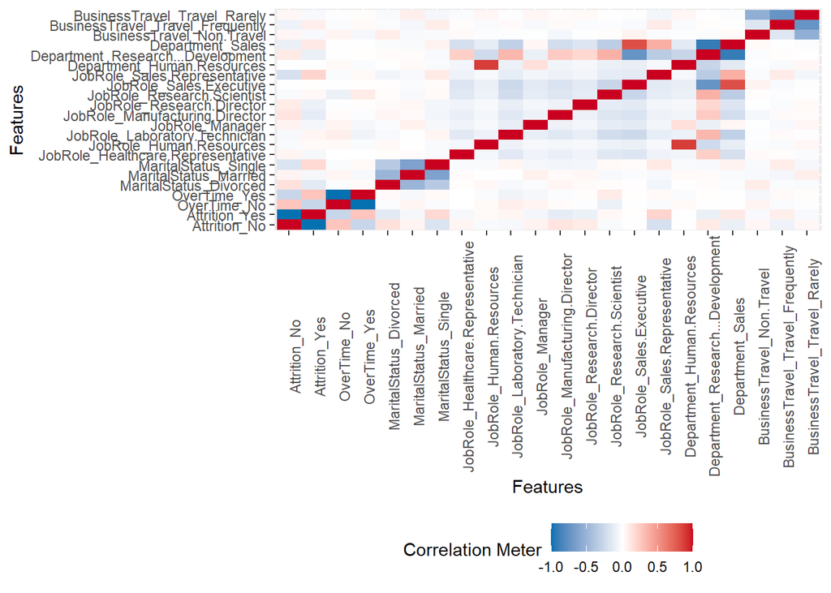

```r
descrete_columns <- raw_employee_data %>%
  select(Attrition, OverTime, MaritalStatus, JobRole, Department, BusinessTravel)
plot_correlation(descrete_columns, type = "d")
```

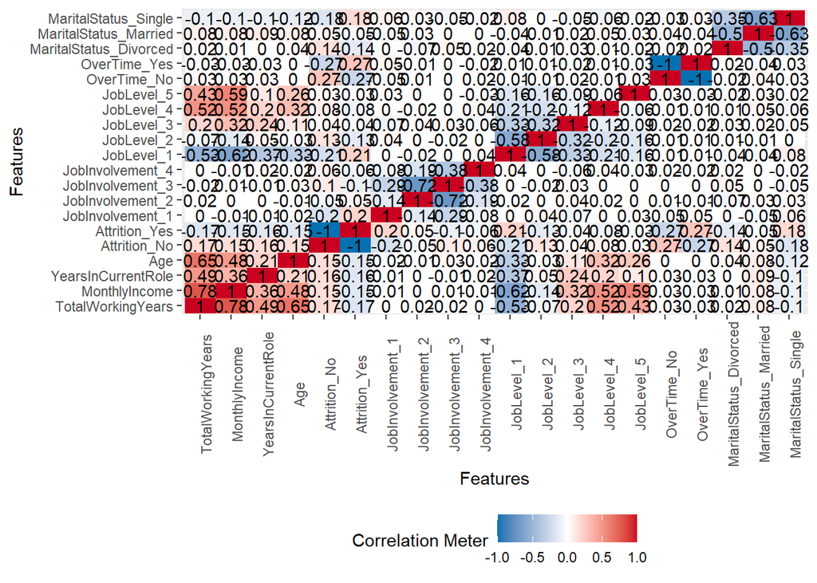

```r
selected_employee_data <- raw_employee_data[, c("Attrition", "JobInvolvement", "TotalWorkingYears", "JobLevel", "MonthlyIncome", "YearsInCurrentRole", "Age", "OverTime", "MaritalStatus")]

plot_correlation(selected_employee_data)
```

Now, let’s generate some visuals for the selected variables categorized by “Attrition” and examine if we can uncover any valuable insights.

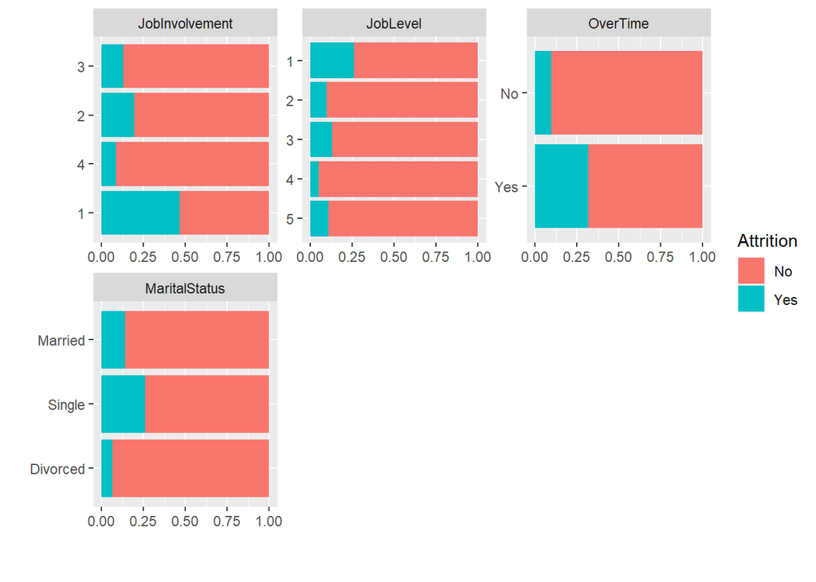

```r
# plot bar for discrete variables broken by attrition:
plot_bar(selected_employee_data, by = "Attrition", ggtheme = theme_gray())
```

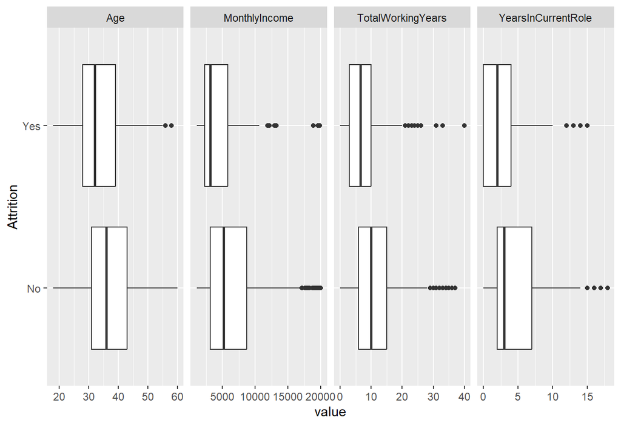

```r
#box plot broken by attrition for continuous variables:
plot_boxplot(selected_employee_data, by = "Attrition", ggtheme = theme_gray())
```

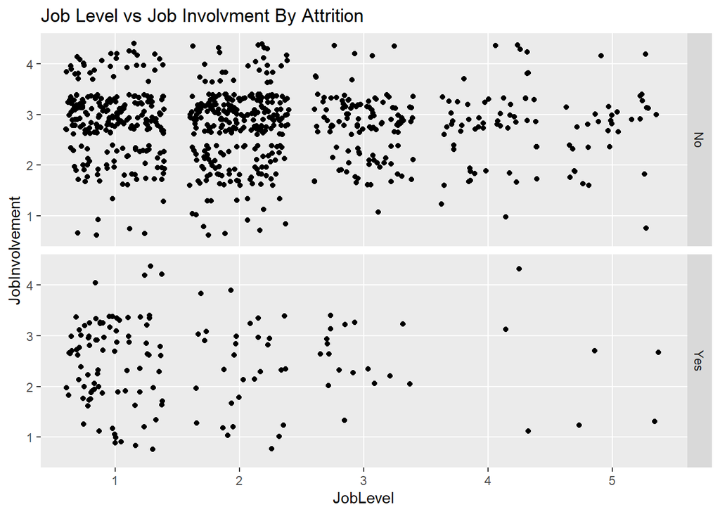

```r
selected_employee_data %>% ggplot(aes(JobLevel, JobInvolvement)) +
  geom_point(position = "jitter") +
  facet_grid(Attrition ~ .) +
  default_ggtheme +
  ggtitle("Job Level vs Job Involvment By Attrition")
```

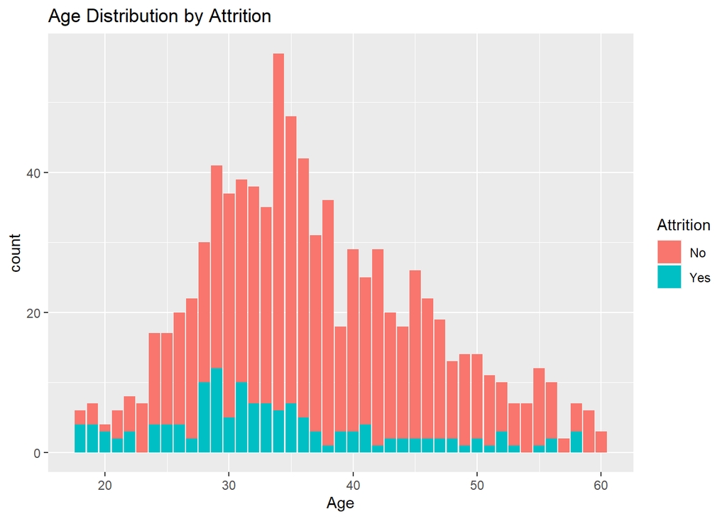

```r
selected_employee_data %>%
  ggplot(mapping = aes(x = Age, fill = Attrition)) +
  geom_bar() +
  default_ggtheme +
  ggtitle("Age Distribution by Attrition")
```

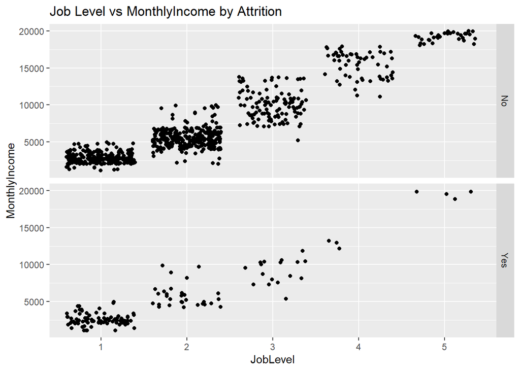

```r
# job level vs monthly income by attrition
selected_employee_data %>% ggplot(aes(JobLevel, MonthlyIncome)) +
  geom_point(position = "jitter") +
  facet_grid(Attrition ~ .) +
  default_ggtheme +
  ggtitle("Job Level vs MonthlyIncome by Attrition")
```

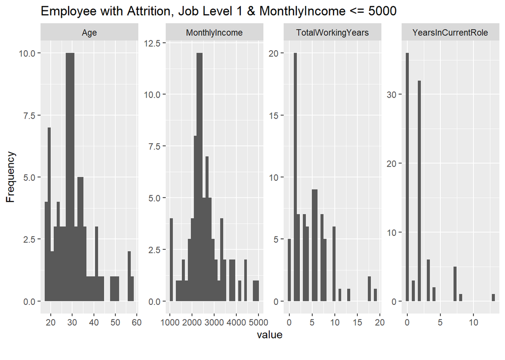

```r
# zooming into employee with attrition and job level 1 with income less than 5000
plot_histogram(selected_employee_data %>%
  filter(JobLevel == 1, MonthlyIncome <= 5000, Attrition == "Yes"), ggtheme = theme_gray(),
               title = "Employee with Attrition, Job Level 1 & MonthlyIncome <= 5000")
```

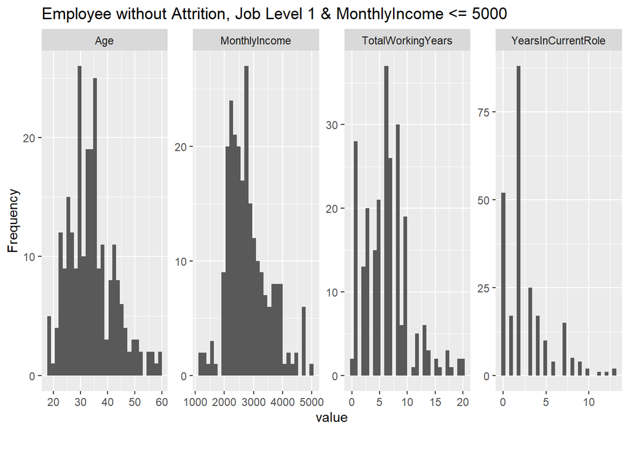

```r
# zooming into employee without attrition and job level 1 with income less than 5000
plot_histogram(selected_employee_data %>%
  filter(JobLevel == 1, MonthlyIncome <= 5000, Attrition == "No"), ggtheme = theme_gray(),
               title = "Employee without Attrition, Job Level 1 & MonthlyIncome <= 5000")
```

```r
selected_employee_data %>% filter(JobLevel == 1, MonthlyIncome <= 5000) %>%
  group_by(Attrition) %>%
  summarise(AverageMonthlyIncome = mean(MonthlyIncome),
            AverageTotalWorkingYears = mean(TotalWorkingYears),
            AverageAge = mean(Age),
            AverageYearsInCurrentRole = mean(YearsInCurrentRole),
            count = n())
```

```
## # A tibble: 2 × 6
##   Attrition AverageMonthlyIncome AverageTotalWorkingYears AverageAge
##   <fct>                    <dbl>                    <dbl>      <dbl>
## 1 No                       2803.                     6.38       33.9
## 2 Yes                      2578.                     4.72       30.5
## # ℹ 2 more variables: AverageYearsInCurrentRole <dbl>, count <int>
```

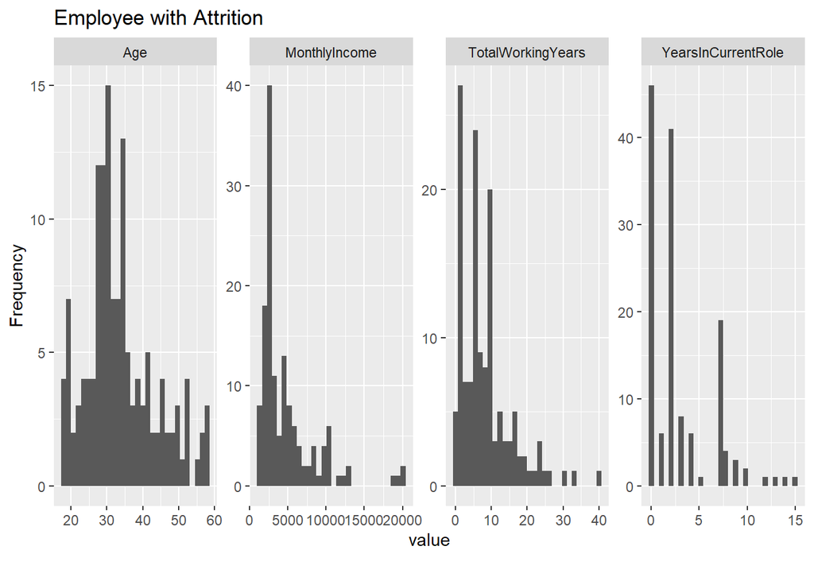

```r
# employee with attrition
selected_employee_data_with_attrition <- selected_employee_data %>%
  filter(Attrition == "Yes")

# employee without attrition
selected_employee_data_without_attrition <- selected_employee_data %>%
  filter(Attrition == "No")

plot_histogram(selected_employee_data_with_attrition, ggtheme = theme_gray(),
               title = "Employee with Attrition")
```

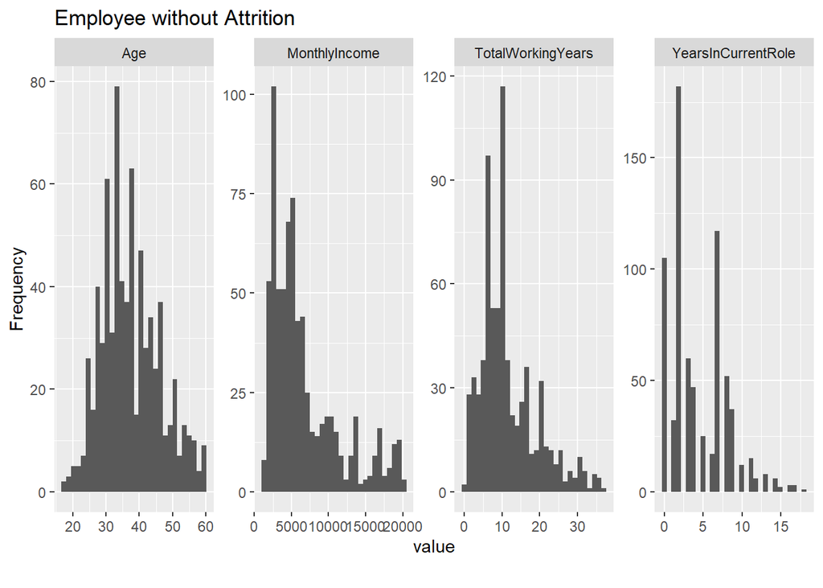

```r
plot_histogram(selected_employee_data_without_attrition, ggtheme = theme_gray(),
               title = "Employee without Attrition")
```

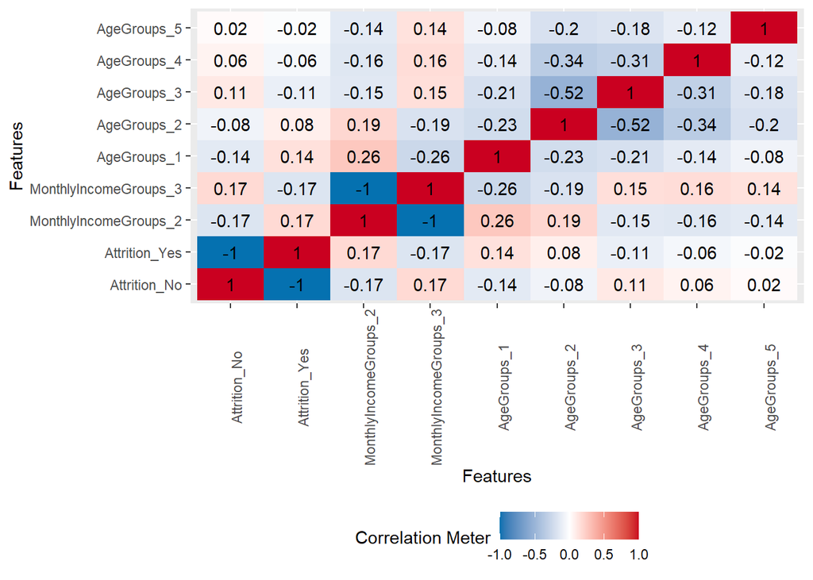

```r
# Let's define breaks for binning age into 5 increments because there see to be a specific age range that are
# more likely to attrition, might help optimizing our model.
AgeBreaks <- seq(min(selected_employee_data$Age) - 1, max(selected_employee_data$Age) + 1, length.out = 6)
selected_employee_data$AgeGroups <- as.factor(cut(selected_employee_data$Age, breaks = AgeBreaks, labels = FALSE))

# similar for monthly income groups, employee with less than 5000 monthly income are more likely to attrition
selected_employee_data$MonthlyIncomeGroups <- as.factor(cut(selected_employee_data$MonthlyIncome,
                                                             breaks = c(-Inf,5000,1000,Inf), labels = FALSE))

plot_correlation(selected_employee_data[, c("Attrition", "MonthlyIncomeGroups", "AgeGroups")], ggtheme = theme_gray())
```

## Naive Bayes Classification:

Naive Bayes is a classification-supervised machine learning algorithm based on Bayes’ Theorem, assuming independence among features. It’s beneficial for classification tasks, such as predicting whether an email is spam or not. The Naive Bayes Classification leverages probabilities to make predictions. For instance, spam detection calculates the likelihood that an email is spam, given the occurrence of certain words.

```r
# select the features to be used in NB modeling:
employee_data_attrition_nb <- raw_employee_data[, c("Attrition", "JobInvolvement", "TotalWorkingYears", "JobLevel", "MonthlyIncome", "YearsInCurrentRole", "Age", "OverTime", "MaritalStatus", "JobSatisfaction", "Department", "JobRole", "YearsWithCurrManager", "StockOptionLevel", "WorkLifeBalance", "EnvironmentSatisfaction", "YearsAtCompany")]


employee_data_attrition_nb <- prepare_data(employee_data_attrition_nb)

# selected feature for NB fitting:
nb_features_attrition <- c("AgeGroups", "MonthlyIncomeGroups", "TotalWorkingYears", "YearsAtCompany", "YearsInCurrentRole",
             "YearsWithCurrManager", "OverTime", "WorkLifeBalance", "MaritalStatus", "Department", "EnvironmentSatisfaction", "JobInvolvement", "StockOptionLevel", "JobLevel")

#nb_features_attrition <- c("AgeGroups", "JobSatisfaction", "MonthlyIncomeGroups")

# random_seeds <- sample(1:10000, 100)
# best_specificity <- -Inf
# best_seed <- -Inf
#
# for(seed in random_seeds) {
#   set.seed(seed)
#   split_perc <- 0.65
#   n <- dim(employee_data_attrition_nb)[1]
#   indices <- sample(1:n, size = round(split_perc * n))
#   training_set <- employee_data_attrition_nb[indices,]
#   testing_set <- employee_data_attrition_nb[-indices,]
#
#
#   train_control = trainControl(method = "repeatedcv", number = 200, repeats = 7)
#   # create the nb model
#   naive_bayes_model = train(x = employee_data_attrition_nb[,nb_features_attrition],
#                     y = as.factor(employee_data_attrition_nb$Attrition),
#                     method = "naive_bayes",
#                     trControl = train_control,
#                     tuneLength = 20)
#
#
#   # predictions using the nb model:
#   predictions <- predict(naive_bayes_model, testing_set[,nb_features_attrition])
#
#   # confusion matrix
#   naive_bayes_model_cm = confusionMatrix(table(predictions, as.factor(testing_set$Attrition)))
#   print(naive_bayes_model_cm)
#
#   if(naive_bayes_model_cm$byClass["Specificity"] > best_specificity) {
#     best_seed <- seed
#     best_specificity <- naive_bayes_model_cm$byClass["Specificity"]
#   }
# }

set.seed(seed_value)
n <- dim(employee_data_attrition_nb)[1]
indices <- sample(1:n, size = round(split_perc * n))
training_set <- employee_data_attrition_nb[indices,]
testing_set <- employee_data_attrition_nb[-indices,]

# given the imbalance of our data set, let's use the cross validation to maximize the accuracy of our model.
train_control = trainControl(method = "repeatedcv", number = 200, repeats = 7)
# create the nb model
naive_bayes_model = train(x = employee_data_attrition_nb[,nb_features_attrition],
                  y = as.factor(employee_data_attrition_nb$Attrition),
                  method = "naive_bayes",
                  trControl = train_control,
                  tuneLength = 20)
# predictions using the nb model:
predictions <- predict(naive_bayes_model, testing_set[,nb_features_attrition])

# confusion matrix
naive_bayes_model_cm = confusionMatrix(table(predictions, as.factor(testing_set$Attrition)))
print(naive_bayes_model_cm)
```

```
## Confusion Matrix and Statistics
##
##
## predictions  No Yes
##         No  249  14
##         Yes  14  27
##
##                Accuracy : 0.9079
##                  95% CI : (0.8696, 0.9379)
##     No Information Rate : 0.8651
##     P-Value [Acc > NIR] : 0.01458
##
##                   Kappa : 0.6053
##
##  Mcnemar's Test P-Value : 1.00000
##
##             Sensitivity : 0.9468
##             Specificity : 0.6585
##          Pos Pred Value : 0.9468
##          Neg Pred Value : 0.6585
##              Prevalence : 0.8651
##          Detection Rate : 0.8191
##    Detection Prevalence : 0.8651
##       Balanced Accuracy : 0.8027
##
##        'Positive' Class : No
##
```

```r
# predict for the raw_employee_data_with_no_attrition
raw_employee_data_with_no_attrition <- prepare_data_with_no_attrition(raw_employee_data_with_no_attrition)
predictions_with_no_attrition <- predict(naive_bayes_model, raw_employee_data_with_no_attrition[,nb_features_attrition])

print(predictions_with_no_attrition)
```

```
##   [1] No  No  Yes No  No  No  No  No  No  No  No  Yes No  No  Yes No  No  No
##  [19] No  No  Yes No  No  Yes No  No  No  Yes No  Yes Yes No  No  No  Yes No
##  [37] No  No  No  No  No  Yes No  No  Yes No  No  No  No  No  No  No  No  No
##  [55] No  No  No  No  No  No  No  No  Yes No  No  No  No  No  No  No  No  No
##  [73] No  No  No  No  No  No  No  No  No  No  No  No  No  No  No  No  No  No
##  [91] No  No  No  No  No  No  No  No  No  Yes Yes No  No  No  Yes No  No  No
## [109] No  No  No  No  No  No  No  No  No  No  Yes No  No  No  No  No  No  No
## [127] Yes No  No  No  No  No  No  Yes No  No  No  No  Yes No  No  No  No  No
## [145] No  No  Yes Yes No  No  No  No  No  No  Yes No  No  No  Yes No  No  No
## [163] No  No  No  No  No  No  No  No  Yes No  No  Yes No  No  No  Yes No  No
## [181] Yes No  No  No  No  No  No  Yes No  No  No  No  No  No  No  Yes No  No
## [199] No  No  No  No  No  No  No  No  No  No  No  No  No  No  No  No  No  No
## [217] No  No  No  No  No  No  No  No  No  No  No  No  No  No  Yes Yes No  Yes
## [235] No  No  Yes No  No  No  Yes No  No  No  No  No  Yes Yes No  Yes Yes No
## [253] No  Yes No  No  No  No  No  No  No  No  No  No  No  No  No  No  Yes No
## [271] No  Yes No  Yes Yes No  No  No  No  Yes No  No  No  No  No  Yes No  Yes
## [289] No  Yes No  No  No  No  Yes No  No  Yes No  No
## Levels: No Yes
```

```r
# output the results into csv:
predicitions_attrition_df = cbind.data.frame(raw_employee_data_with_no_attrition$ID, predictions_with_no_attrition)
colnames(predicitions_attrition_df) <- c("Id", "Attrition")
write.csv(predicitions_attrition_df, file ="ahmad_salama_nb_Case2PredictionsAttrition.csv", row.names = FALSE)
```

## k-Nearest Neighbors Classification (KNN)

KNN is a classification-supervised machine learning algorithm. Basically, when you want to predict something for a new data point, the model looks at the “neighbors” or data points that are closest to it. The decision for the new data point is based on the majority of its nearest neighbors. If the majority belongs to a a certain category, the KNN classification model predicts that the new data point belongs to that category.

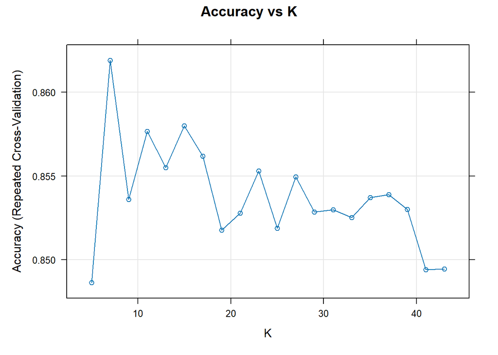

```r
# select the features to be used in KNN modeling:
employee_data_attrition_knn <- raw_employee_data[, c("Attrition", "JobInvolvement", "TotalWorkingYears", "JobLevel", "MonthlyIncome", "YearsInCurrentRole", "Age", "OverTime", "MaritalStatus", "JobSatisfaction", "Department", "YearsWithCurrManager", "StockOptionLevel", "WorkLifeBalance", "EnvironmentSatisfaction", "YearsAtCompany", "JobRole")]

employee_data_attrition_knn <- prepare_data(employee_data_attrition_knn)
employee_data_attrition_knn$Department <- as.integer(employee_data_attrition_knn$Department)
employee_data_attrition_knn$MaritalStatus <- as.integer(employee_data_attrition_knn$MaritalStatus)
employee_data_attrition_knn$OverTime <- as.integer(employee_data_attrition_knn$OverTime)

knn_features_attrition <- c("AgeGroups", "MonthlyIncomeGroups", "TotalWorkingYears", "YearsAtCompany", "YearsInCurrentRole",
             "YearsWithCurrManager", "OverTime", "WorkLifeBalance", "MaritalStatus", "Department", "EnvironmentSatisfaction", "JobInvolvement", "StockOptionLevel", "JobLevel")


# Since we have an imbalanced data, we are going to apply cross-validation to measure the performance of our KNN model:
# controls the computational nuances of the train() method.
# param: - method: re-sampling method: “cv” vs “repeatedcv”
# - “number” parameter holds the number of re-sampling iterations.
# - “repeats ” parameter contains the complete sets of folds to compute for our repeated cross-validation.
train_control = trainControl(method = "repeatedcv", number = 120, repeats = 7)

# create the KNN model
knn_model = train(x = employee_data_attrition_knn[,knn_features_attrition],
                  y = as.factor(employee_data_attrition_knn$Attrition),
                  method = "knn",
                  trControl = train_control,
                  # scale the  of the selected features
                  preProcess = c("scale"),
                  tuneLength = 20)
# plot the KNN Accuracy vs K
plot(knn_model, main = "Accuracy vs K", xlab = "K")
```

```r
# use the model to predict using the testing data set:
test_predictions <- predict(knn_model, newdata = employee_data_attrition_knn[,knn_features_attrition])
# confusion matrix
knn_cm = confusionMatrix(table(test_predictions,
                               as.factor(employee_data_attrition_knn$Attrition)))
print(knn_cm)
```

```
## Confusion Matrix and Statistics
##
##
## test_predictions  No Yes
##              No  715  89
##              Yes  15  51
##
##                Accuracy : 0.8805
##                  95% CI : (0.857, 0.9013)
##     No Information Rate : 0.8391
##     P-Value [Acc > NIR] : 0.000348
##
##                   Kappa : 0.4371
##
##  Mcnemar's Test P-Value : 8.172e-13
##
##             Sensitivity : 0.9795
##             Specificity : 0.3643
##          Pos Pred Value : 0.8893
##          Neg Pred Value : 0.7727
##              Prevalence : 0.8391
##          Detection Rate : 0.8218
##    Detection Prevalence : 0.9241
##       Balanced Accuracy : 0.6719
##
##        'Positive' Class : No
##
```

## Linear Regression: Monthly Income:

```r
# Linear Regression
set.seed(seed_value)
n <- dim(raw_employee_data)[1]
indices <- sample(1:n, size = round(split_perc * n))
training_set <- raw_employee_data[indices,]
testing_set <- raw_employee_data[-indices,]

monthly_income_model = lm(formula = MonthlyIncome ~ JobLevel +
            TotalWorkingYears, data = training_set)

summary(monthly_income_model)
```

```
##
## Call:
## lm(formula = MonthlyIncome ~ JobLevel + TotalWorkingYears, data = training_set)
##
## Residuals:
##     Min      1Q  Median      3Q     Max
## -4908.8  -631.5   -94.9   645.1  4467.3
##
## Coefficients:
##                   Estimate Std. Error t value Pr(>|t|)
## (Intercept)        2598.31     108.89  23.862   <2e-16 ***
## JobLevel2          2778.93     136.63  20.339   <2e-16 ***
## JobLevel3          7134.74     198.01  36.032   <2e-16 ***
## JobLevel4         12187.95     327.45  37.221   <2e-16 ***
## JobLevel5         16154.98     348.62  46.340   <2e-16 ***
## TotalWorkingYears    16.07      11.66   1.378    0.169
## ---
## Signif. codes:  0 '***' 0.001 '**' 0.01 '*' 0.05 '.' 0.1 ' ' 1
##
## Residual standard error: 1268 on 560 degrees of freedom
## Multiple R-squared:  0.9282, Adjusted R-squared:  0.9275
## F-statistic:  1447 on 5 and 560 DF,  p-value: < 2.2e-16
```

```r
confint(monthly_income_model)
```

```
##                         2.5 %      97.5 %
## (Intercept)        2384.42917  2812.20057
## JobLevel2          2510.55915  3047.29497
## JobLevel3          6745.80417  7523.67205
## JobLevel4         11544.77093 12831.12872
## JobLevel5         15470.21299 16839.74575
## TotalWorkingYears    -6.83542    38.98024
```

```r
predictions = predict(monthly_income_model, testing_set)
print(paste("MSPE: ", mean((testing_set$MonthlyIncome - predictions)^2)))
```

```
## [1] "MSPE:  1548074.00311717"
```

```r
print(paste("RMSE: ", RMSE(testing_set$MonthlyIncome, predictions)))
```

```
## [1] "RMSE:  1244.2162204043"
```

```r
# predict monthly comp. for data set with no comp using the linear model.
predictions_with_no_comp = predict(monthly_income_model, raw_employee_data_with_no_comp)
print(round(predictions_with_no_comp))
```

```
##     1     2     3     4     5     6     7     8     9    10    11    12    13
##  5490  2679 15172  2679  2711  5683  5506  2630  2759 15252 10183  2711  5474
##    14    15    16    17    18    19    20    21    22    23    24    25    26
##  5458  5538  5442  5554  5490  5538  2695  5522  9878  9878  5474 10199  9926
##    27    28    29    30    31    32    33    34    35    36    37    38    39
##  9910 15124  5538  2695  2695  5554  5667  2727 15204  5442 10071  5506  2630
##    40    41    42    43    44    45    46    47    48    49    50    51    52
##  2614 19155  2711  2711  9958  5506  5458  2647  5458  2614  2791  2663  2614
##    53    54    55    56    57    58    59    60    61    62    63    64    65
##  5522  5538 15365  2759  5538 10055  2614  2727  5618  9894  9894  2647  2614
##    66    67    68    69    70    71    72    73    74    75    76    77    78
##  2663 10006 10022  5667  2614  2839  9910 10183  5442  2598  5474  2614  2647
##    79    80    81    82    83    84    85    86    87    88    89    90    91
##  2727  5506  2759  5506  5506  2695  5522  9878 10328  2759 10071 19396  2695
##    92    93    94    95    96    97    98    99   100   101   102   103   104
```

[output cut: 33 more lines]

```r
# output the results into csv:
predicitions_montly_income_df = cbind.data.frame(raw_employee_data_with_no_comp$ID, round(predictions_with_no_comp))
colnames(predicitions_montly_income_df) <- c("Id", "MonthlyIncome")
write.csv(predicitions_montly_income_df, file ="ahmad_salama_ln_CaseStudy2CompSetNoSalary.csv", row.names = FALSE)
```